# Part I - Exploratory Data Analysis: Prosper Loan Dataset

## Introduction

This data set contains 113,937 loans with 81 variables on each loan, including loan amount, borrower rate (or interest rate), current loan status, borrower income, and many others.

## Preliminary Wrangling

```python
# importing libraries
import pandas as pd
import numpy as np
import matplotlib.pyplot as plt
import seaborn as sns
import warnings

warnings.filterwarnings('ignore')

%matplotlib inline
```

- I will be reading the comma seperated value dataset(Prosper Loan Data)into my Notebook.

```python
# loading dataset into 'loan_data' dataframe
loandata = pd.read_csv('prosperLoanData.csv')
```

```python
# To get the total number of rows and column
loandata.shape
```

```
(113937, 81)
```

```python
# This is to see what the dataset looks like by vewing the first 8 rows
loandata.head(8)
```

|  | ListingKey | ListingNumber | ListingCreationDate | CreditGrade | Term | LoanStatus | ClosedDate | BorrowerAPR | BorrowerRate | LenderYield | ... | LP_ServiceFees | LP_CollectionFees | LP_GrossPrincipalLoss | LP_NetPrincipalLoss | LP_NonPrincipalRecoverypayments | PercentFunded | Recommendations | InvestmentFromFriendsCount | InvestmentFromFriendsAmount | Investors |
| --- | --- | --- | --- | --- | --- | --- | --- | --- | --- | --- | --- | --- | --- | --- | --- | --- | --- | --- | --- | --- | --- |
| 0 | 1021339766868145413AB3B | 193129 | 2007-08-26 19:09:29.263000000 | C | 36 | Completed | 2009-08-14 00:00:00 | 0.16516 | 0.1580 | 0.1380 | ... | -133.18 | 0.0 | 0.0 | 0.0 | 0.0 | 1.0 | 0 | 0 | 0.0 | 258 |
| 1 | 10273602499503308B223C1 | 1209647 | 2014-02-27 08:28:07.900000000 | NaN | 36 | Current | NaN | 0.12016 | 0.0920 | 0.0820 | ... | 0.00 | 0.0 | 0.0 | 0.0 | 0.0 | 1.0 | 0 | 0 | 0.0 | 1 |
| 2 | 0EE9337825851032864889A | 81716 | 2007-01-05 15:00:47.090000000 | HR | 36 | Completed | 2009-12-17 00:00:00 | 0.28269 | 0.2750 | 0.2400 | ... | -24.20 | 0.0 | 0.0 | 0.0 | 0.0 | 1.0 | 0 | 0 | 0.0 | 41 |
| 3 | 0EF5356002482715299901A | 658116 | 2012-10-22 11:02:35.010000000 | NaN | 36 | Current | NaN | 0.12528 | 0.0974 | 0.0874 | ... | -108.01 | 0.0 | 0.0 | 0.0 | 0.0 | 1.0 | 0 | 0 | 0.0 | 158 |
| 4 | 0F023589499656230C5E3E2 | 909464 | 2013-09-14 18:38:39.097000000 | NaN | 36 | Current | NaN | 0.24614 | 0.2085 | 0.1985 | ... | -60.27 | 0.0 | 0.0 | 0.0 | 0.0 | 1.0 | 0 | 0 | 0.0 | 20 |
| 5 | 0F05359734824199381F61D | 1074836 | 2013-12-14 08:26:37.093000000 | NaN | 60 | Current | NaN | 0.15425 | 0.1314 | 0.1214 | ... | -25.33 | 0.0 | 0.0 | 0.0 | 0.0 | 1.0 | 0 | 0 | 0.0 | 1 |
| 6 | 0F0A3576754255009D63151 | 750899 | 2013-04-12 09:52:56.147000000 | NaN | 36 | Current | NaN | 0.31032 | 0.2712 | 0.2612 | ... | -22.95 | 0.0 | 0.0 | 0.0 | 0.0 | 1.0 | 0 | 0 | 0.0 | 1 |
| 7 | 0F1035772717087366F9EA7 | 768193 | 2013-05-05 06:49:27.493000000 | NaN | 36 | Current | NaN | 0.23939 | 0.2019 | 0.1919 | ... | -69.21 | 0.0 | 0.0 | 0.0 | 0.0 | 1.0 | 0 | 0 | 0.0 | 1 |

8 rows × 81 columns

```python
# This is to view the total numbr of columns in my dataset
loandata.columns
```

```
Index(['ListingKey', 'ListingNumber', 'ListingCreationDate', 'CreditGrade',
       'Term', 'LoanStatus', 'ClosedDate', 'BorrowerAPR', 'BorrowerRate',
       'LenderYield', 'EstimatedEffectiveYield', 'EstimatedLoss',
       'EstimatedReturn', 'ProsperRating (numeric)', 'ProsperRating (Alpha)',
       'ProsperScore', 'ListingCategory (numeric)', 'BorrowerState',
       'Occupation', 'EmploymentStatus', 'EmploymentStatusDuration',
       'IsBorrowerHomeowner', 'CurrentlyInGroup', 'GroupKey',
       'DateCreditPulled', 'CreditScoreRangeLower', 'CreditScoreRangeUpper',
       'FirstRecordedCreditLine', 'CurrentCreditLines', 'OpenCreditLines',
       'TotalCreditLinespast7years', 'OpenRevolvingAccounts',
       'OpenRevolvingMonthlyPayment', 'InquiriesLast6Months', 'TotalInquiries',
       'CurrentDelinquencies', 'AmountDelinquent', 'DelinquenciesLast7Years',
       'PublicRecordsLast10Years', 'PublicRecordsLast12Months',
       'RevolvingCreditBalance', 'BankcardUtilization',
       'AvailableBankcardCredit', 'TotalTrades',
       'TradesNeverDelinquent (percentage)', 'TradesOpenedLast6Months',
       'DebtToIncomeRatio', 'IncomeRange', 'IncomeVerifiable',
       'StatedMonthlyIncome', 'LoanKey', 'TotalProsperLoans',
       'TotalProsperPaymentsBilled', 'OnTimeProsperPayments',
       'ProsperPaymentsLessThanOneMonthLate',
       'ProsperPaymentsOneMonthPlusLate', 'ProsperPrincipalBorrowed',
       'ProsperPrincipalOutstanding', 'ScorexChangeAtTimeOfListing',
       'LoanCurrentDaysDelinquent', 'LoanFirstDefaultedCycleNumber',
       'LoanMonthsSinceOrigination', 'LoanNumber', 'LoanOriginalAmount',
       'LoanOriginationDate', 'LoanOriginationQuarter', 'MemberKey',
       'MonthlyLoanPayment', 'LP_CustomerPayments',
       'LP_CustomerPrincipalPayments', 'LP_InterestandFees', 'LP_ServiceFees',
       'LP_CollectionFees', 'LP_GrossPrincipalLoss', 'LP_NetPrincipalLoss',
       'LP_NonPrincipalRecoverypayments', 'PercentFunded', 'Recommendations',
       'InvestmentFromFriendsCount', 'InvestmentFromFriendsAmount',
       'Investors'],
      dtype='object')
```

```python
# Thr coumns that would be used for analysis and the count.

columns = ['ListingCreationDate', 'Term', 'LoanStatus', 'ClosedDate', 'BorrowerAPR',
                         'BorrowerRate', 'LenderYield', 'ProsperRating (Alpha)', 'ProsperScore', 'ListingCategory (numeric)',
                         'BorrowerState', 'Occupation', 'EmploymentStatus', 'AmountDelinquent',
                         'IncomeRange', 'StatedMonthlyIncome',
                         'LoanCurrentDaysDelinquent',
                         'LoanOriginalAmount', 'LoanOriginationDate',
                         'MonthlyLoanPayment', 'LP_ServiceFees', 'Investors']

# to confirm the length of the list (columns)
len(columns)
```

```
22
```

```python
# This helps to check the number of rows and colums in the dataframe
loandata.shape
```

```
(113937, 81)
```

```python
# This is to view the first 6 rows of the dataframe
loandata.head(6)
```

|  | ListingKey | ListingNumber | ListingCreationDate | CreditGrade | Term | LoanStatus | ClosedDate | BorrowerAPR | BorrowerRate | LenderYield | ... | LP_ServiceFees | LP_CollectionFees | LP_GrossPrincipalLoss | LP_NetPrincipalLoss | LP_NonPrincipalRecoverypayments | PercentFunded | Recommendations | InvestmentFromFriendsCount | InvestmentFromFriendsAmount | Investors |
| --- | --- | --- | --- | --- | --- | --- | --- | --- | --- | --- | --- | --- | --- | --- | --- | --- | --- | --- | --- | --- | --- |
| 0 | 1021339766868145413AB3B | 193129 | 2007-08-26 19:09:29.263000000 | C | 36 | Completed | 2009-08-14 00:00:00 | 0.16516 | 0.1580 | 0.1380 | ... | -133.18 | 0.0 | 0.0 | 0.0 | 0.0 | 1.0 | 0 | 0 | 0.0 | 258 |
| 1 | 10273602499503308B223C1 | 1209647 | 2014-02-27 08:28:07.900000000 | NaN | 36 | Current | NaN | 0.12016 | 0.0920 | 0.0820 | ... | 0.00 | 0.0 | 0.0 | 0.0 | 0.0 | 1.0 | 0 | 0 | 0.0 | 1 |
| 2 | 0EE9337825851032864889A | 81716 | 2007-01-05 15:00:47.090000000 | HR | 36 | Completed | 2009-12-17 00:00:00 | 0.28269 | 0.2750 | 0.2400 | ... | -24.20 | 0.0 | 0.0 | 0.0 | 0.0 | 1.0 | 0 | 0 | 0.0 | 41 |
| 3 | 0EF5356002482715299901A | 658116 | 2012-10-22 11:02:35.010000000 | NaN | 36 | Current | NaN | 0.12528 | 0.0974 | 0.0874 | ... | -108.01 | 0.0 | 0.0 | 0.0 | 0.0 | 1.0 | 0 | 0 | 0.0 | 158 |
| 4 | 0F023589499656230C5E3E2 | 909464 | 2013-09-14 18:38:39.097000000 | NaN | 36 | Current | NaN | 0.24614 | 0.2085 | 0.1985 | ... | -60.27 | 0.0 | 0.0 | 0.0 | 0.0 | 1.0 | 0 | 0 | 0.0 | 20 |
| 5 | 0F05359734824199381F61D | 1074836 | 2013-12-14 08:26:37.093000000 | NaN | 60 | Current | NaN | 0.15425 | 0.1314 | 0.1214 | ... | -25.33 | 0.0 | 0.0 | 0.0 | 0.0 | 1.0 | 0 | 0 | 0.0 | 1 |

6 rows × 81 columns

```python
# To check for information about the dataset and its corresponding datatype
loandata.info()
```

```
<class 'pandas.core.frame.DataFrame'>
RangeIndex: 113937 entries, 0 to 113936
Data columns (total 81 columns):
 #   Column                               Non-Null Count   Dtype
---  ------                               --------------   -----
 0   ListingKey                           113937 non-null  object
 1   ListingNumber                        113937 non-null  int64
 2   ListingCreationDate                  113937 non-null  object
 3   CreditGrade                          28953 non-null   object
 4   Term                                 113937 non-null  int64
 5   LoanStatus                           113937 non-null  object
 6   ClosedDate                           55089 non-null   object
 7   BorrowerAPR                          113912 non-null  float64
 8   BorrowerRate                         113937 non-null  float64
 9   LenderYield                          113937 non-null  float64
```

[output cut: 73 more lines]

```python
# To confirm the numbers of duplicate records
sum(loandata.duplicated())
```

```
0
```

```python
# To check if there are duplicate listingkey records
sum(loandata['ListingKey'].duplicated())
```

```
871
```

```python
# To check if there are duplicate listingNumber records
sum(loandata['ListingNumber'].duplicated())
```

```
871
```

```python
# To check for duplicates for both fields
sum(loandata[['ListingKey', 'ListingNumber']].duplicated())
```

```
871
```

```python
loandata.isnull().sum()
```

```
ListingKey                         0
ListingNumber                      0
ListingCreationDate                0
CreditGrade                    84984
Term                               0
                               ...
PercentFunded                      0
Recommendations                    0
InvestmentFromFriendsCount         0
InvestmentFromFriendsAmount        0
Investors                          0
Length: 81, dtype: int64
```

```
ListingKey                         0
ListingNumber                      0
ListingCreationDate                0
CreditGrade                    84984
Term                               0
                               ...
PercentFunded                      0
Recommendations                    0
InvestmentFromFriendsCount         0
InvestmentFromFriendsAmount        0
Investors                          0
Length: 81, dtype: int64
```

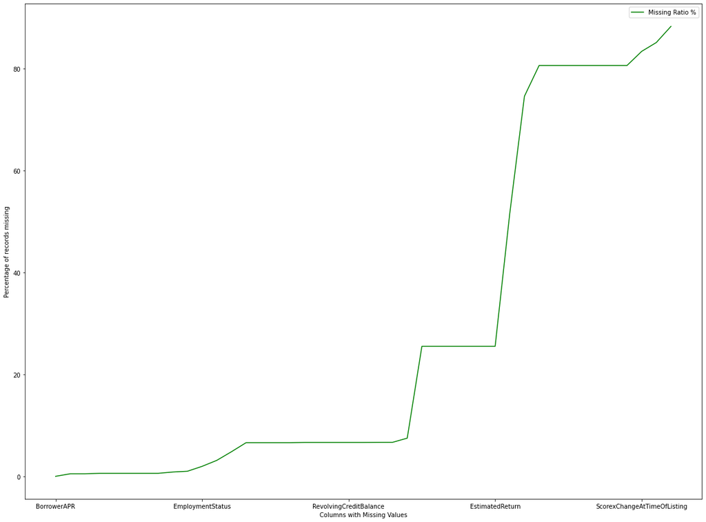

```python
# To check for null values in each columns
null = loandata.isna().sum()
print(null)

# Creating a function to plot the number of null values
def plot_nas(df: pd.DataFrame):
    if df.isnull().sum().sum() != 0:
        na_df = (df.isnull().sum() / len(df)) * 100
        na_df = na_df.drop(na_df[na_df == 0].index).sort_values(ascending= True)
        missing_data = pd.DataFrame({'Missing Ratio %' :na_df})
        missing_data.plot(kind = "line", color = 'green')
        plt.ylabel("Percentage of records missing", fontsize = 10)
        plt.xlabel("Columns with Missing Values", fontsize = 10)
        plt.show()
    else:
        print('No Null found')


plot_nas(loandata)
plot_width, plot_height = (20, 15)
plt.rcParams['figure.figsize'] = (plot_width, plot_height)
```

```python
# To see the number of distinct column in the dataset
loandata.nunique()
```

```
ListingKey                     113066
ListingNumber                  113066
ListingCreationDate            113064
CreditGrade                         8
Term                                3
                                ...
PercentFunded                     719
Recommendations                    17
InvestmentFromFriendsCount         14
InvestmentFromFriendsAmount       726
Investors                         751
Length: 81, dtype: int64
```

```python
#This is to Convert datatype for all other categorical columns and datetime
loandata['Occupation'] = loandata['Occupation'].astype('category')
loandata['BorrowerState'] = loandata['BorrowerState'].astype('category')
loandata['LoanStatus'] = loandata['LoanStatus'].astype('category')
loandata['ListingCategory (numeric)'] = loandata['ListingCategory (numeric)'].astype('category')
loandata['EmploymentStatus'] = loandata['EmploymentStatus'].astype('category')
loandata['ListingCreationDate'] = pd.to_datetime(loandata['ListingCreationDate'])
loandata['ClosedDate'] = pd.to_datetime(loandata['ClosedDate'])
loandata['LoanOriginationDate'] = pd.to_datetime(loandata['LoanOriginationDate'])
loandata.info()
```

```
<class 'pandas.core.frame.DataFrame'>
RangeIndex: 113937 entries, 0 to 113936
Data columns (total 81 columns):
 #   Column                               Non-Null Count   Dtype
---  ------                               --------------   -----
 0   ListingKey                           113937 non-null  object
 1   ListingNumber                        113937 non-null  int64
 2   ListingCreationDate                  113937 non-null  datetime64[ns]
 3   CreditGrade                          28953 non-null   object
 4   Term                                 113937 non-null  int64
 5   LoanStatus                           113937 non-null  category
 6   ClosedDate                           55089 non-null   datetime64[ns]
 7   BorrowerAPR                          113912 non-null  float64
 8   BorrowerRate                         113937 non-null  float64
 9   LenderYield                          113937 non-null  float64
```

[output cut: 73 more lines]

```python
# Converting ProsperRating & IncomeRange to ordinal categorical
ordinal_var_dict = {'ProsperRating (Alpha)': ['N/A','HR','E','D','C', 'B', 'A', 'AA'],
                    'IncomeRange':['$0','$1-24,999','$25,000-49,999','$50,000-74,999','$75,000-99,999','$100,000+']}
for var in ordinal_var_dict:
    ordered_var = pd.api.types.CategoricalDtype(ordered = True, categories = ordinal_var_dict[var])
    loandata[var] = loandata[var].astype(ordered_var)
```

```python
loandata['Occupation'].value_counts()
```

```
Other                          28617
Professional                   13628
Computer Programmer             4478
Executive                       4311
Teacher                         3759
                               ...
Dentist                           68
Student - College Freshman        41
Student - Community College       28
Judge                             22
Student - Technical School        16
Name: Occupation, Length: 67, dtype: int64
```

```python
loandata['IncomeRange'].value_counts()
```

```
$25,000-49,999    32192
$50,000-74,999    31050
$100,000+         17337
$75,000-99,999    16916
$1-24,999          7274
$0                  621
Name: IncomeRange, dtype: int64
```

## EXPLORATORY DATA ANALYSIS

Using summary statistics and graphical representations, exploratory data analysis will be performed in this section to study the data in order to discover insights and form data driven opinions for decision making.

The analysis would be divided into three categories: univariate, bivariate, and multivariate.

## UNIVARIATE ANALYSIS

Analyzing just one variable is referred to as univariate analysis. To comprehend the distribution of values for a single variable, univariate analysis is used.

I will start by looking into the number of loan listings. According to Law Insider, Loan Listing means a request by a Borrower to borrow money on the terms of a Loan. The process of analyzing one variable is regarded as Univariate. To comprehend the distribution of values for a single variable, univariate analysis would be deployed to get few insights.

The following inputs would be looked at

- The loan amount collected based on employment status
- Distrubitions of borrowers based on state
- Borrowing rate based on occupation
- Loan amount that is frequently requested
- The most loan term required by borrowers
- The distriution of borrowers based on their Prosper score

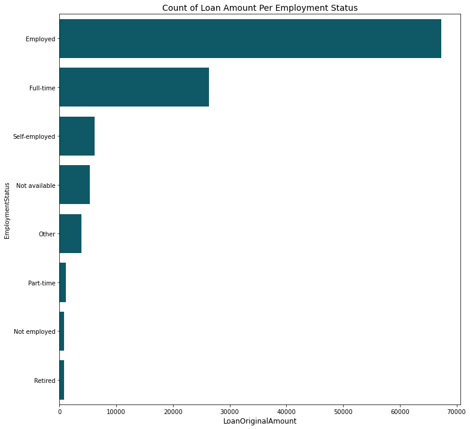

```python
# To view Tthe loan amount collected based on employment status
def countploty(y):
    plt.figure(figsize = [12,12])
    base_color = sns.color_palette("dark")[9]
    sns.countplot(data=loandata, y = y, color = base_color, order = loandata[y].value_counts().index)

# to plot the count plot
countploty('EmploymentStatus')
plt.xlabel('LoanOriginalAmount', fontsize = 12)
plt.title('Count of Loan Amount Per Employment Status', fontsize = 14)
plt.show();
```

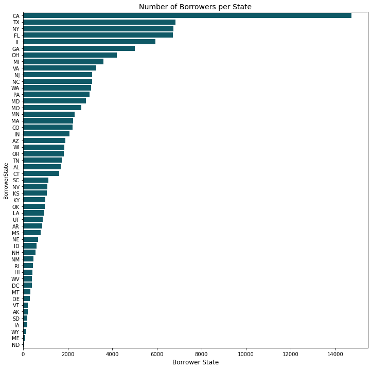

```python
#This is to check which state are most borrowers located.
countploty('BorrowerState')
plt.xlabel('Borrower State', fontsize = 12)
plt.title('Number of Borrowers per State', fontsize = 14)
plt.show();
```

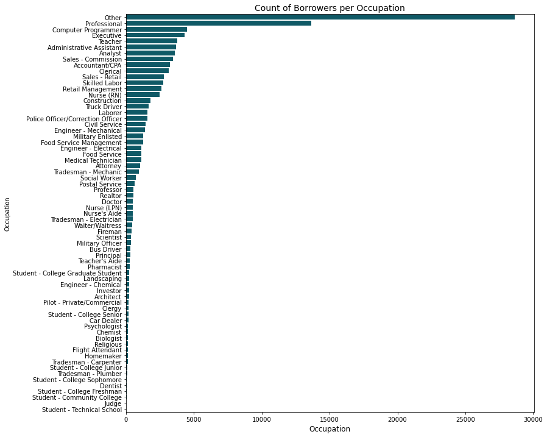

```python
# To view borrowing rate based on occupation
countploty('Occupation')
plt.xlabel('Occupation', fontsize = 12)
plt.title('Count of Borrowers per Occupation', fontsize = 14)
plt.show();
```

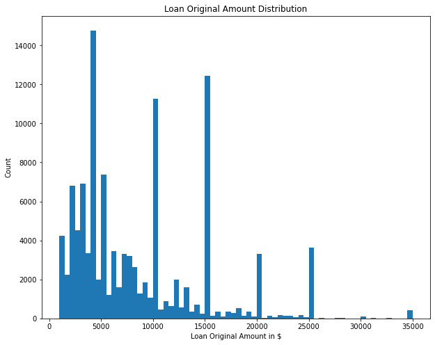

```python
# To view the Loan amount that is frequently borrowed
binsize = 500
bins = np.arange(loandata['LoanOriginalAmount'].min(), loandata['LoanOriginalAmount'].max()+binsize, binsize)

plt.figure(figsize=[10, 8])
plt.hist(data = loandata, x = 'LoanOriginalAmount', bins = bins)
plt.title('Loan Original Amount Distribution')
plt.xlabel('Loan Original Amount in $')
plt.ylabel('Count')
plt.show()
```

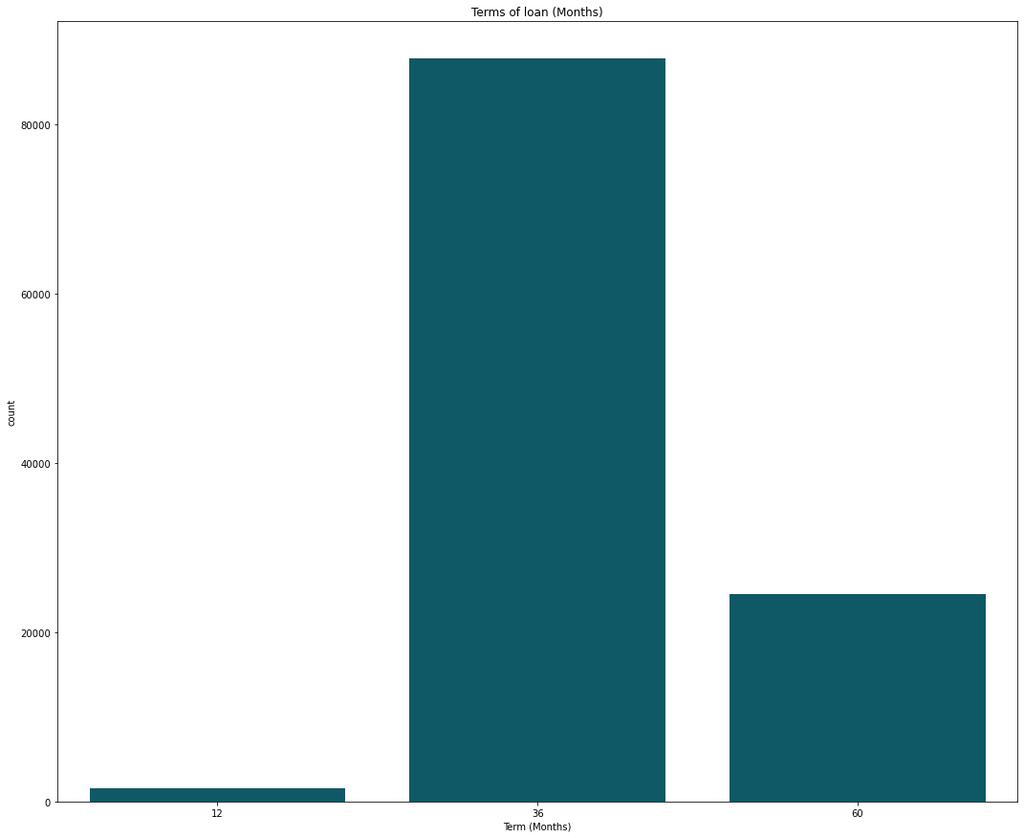

```python
# The visualization for the most loan term required by borrowers
base_color = sns.color_palette("dark")[9]
sns.countplot(data=loandata,x= 'Term',color=base_color);
plt.title('Terms of loan (Months)')
plt.xlabel('Term (Months)');
```

- From the graph we can see that the 36 months has the most recurring values for borrowers term.

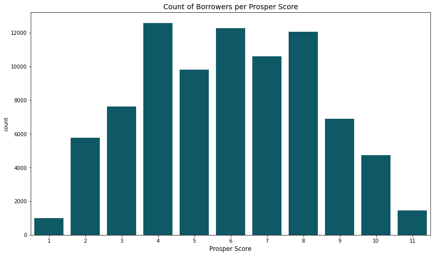

```python
# The graph reprensation for the distriution of borrowers based on Prosper score
order = [1, 2, 3, 4, 5, 6, 7, 8, 9, 10, 11]
plt.figure(figsize = [14,8])
base_color = sns.color_palette("dark")[9]
sns.countplot(data=loandata, x = 'ProsperScore', color = base_color, order = order)
plt.xlabel('Prosper Score', fontsize = 12)
plt.title('Count of Borrowers per Prosper Score', fontsize = 14)
plt.show();
```

- From the visuals we can tell that most of the borrowers are people whose prosper score fall between 4, 6 and 8 while the he lowest prosper score is 1 and 11.

## Bivariate Analysis

This looks for yny concurrent link between two variables or attributes. This study evaluates the link between the two variables as well as the strength of their association in order to ascertain whether there are is any relationship between the two variables and to what extent is there a change between both variables.

Question:

- The impact of recommendations on loan status *.The association between monthly income and loan amount requested by borrowers
- The effect of APR on loan status
- The relaionship between income amount and occupation
- Determine states with high and low loan amount
- The distribution of Borrowers APR based on Term
- The Distribution of Debt to income ration based on Prosper Score

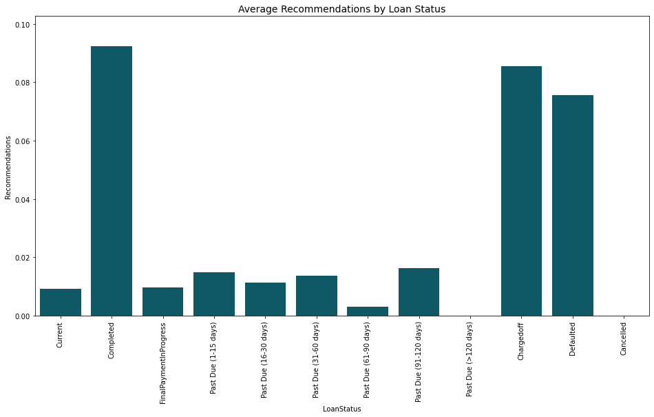

```python
# The impact of recommendations on loan status
here = ['Current', 'Completed', 'FinalPaymentInProgress', 'Past Due (1-15 days)', 'Past Due (16-30 days)',
        'Past Due (31-60 days)', 'Past Due (61-90 days)', 'Past Due (91-120 days)', 'Past Due (>120 days)',
        'Chargedoff', 'Defaulted', 'Cancelled']
plt.figure(figsize = [16, 8])
base_color = sns.color_palette("dark")[9]
sns.barplot(data = loandata, x = 'LoanStatus', y = 'Recommendations', color = base_color, errwidth = 0,
           order=here)
plt.ylabel("Recommendations")
plt.title("Average Recommendations by Loan Status", fontsize = 14)
plt.xticks(rotation = 90);
```

- According to the chart, "Completed" Loan Status is recommended more often than Average. The quantity of recommendations may have an impact on loan status.

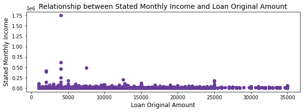

```python
# Checking for association between monthly income and loan amount requested by borrowers
plt.figure(figsize=(10,3))
base_color = sns.color_palette("Paired")[9]
plt.scatter(loandata['LoanOriginalAmount'], loandata['StatedMonthlyIncome'], color=base_color)
plt.xlabel('Loan Original Amount', fontsize = 12)
plt.ylabel('Stated Monthly Income', fontsize = 12)
plt.title('Relationship between Stated Monthly Income and Loan Original Amount', fontsize = 14)
plt.show()
```

- The distribution of the visuals does not suggest any skewed relationship between monntly income and loan original amount

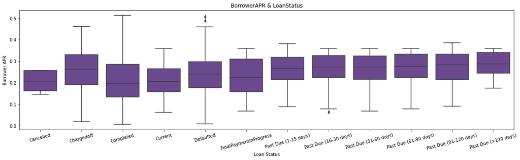

```python
# The distribution of APR vs loan status
plt.figure(figsize = [20, 5])
sns.boxplot(data=loandata,y='BorrowerAPR',x='LoanStatus',color=base_color);
plt.title('BorrowerAPR & LoanStatus');
plt.ylabel('Borrower APR');
plt.xlabel('Loan Status');
plt.xticks(rotation=15);
```

- We can observe that current and completed loans have lower rates and mean values than past-due loans on the graph of BorrowerAPR vs LoanStatus.

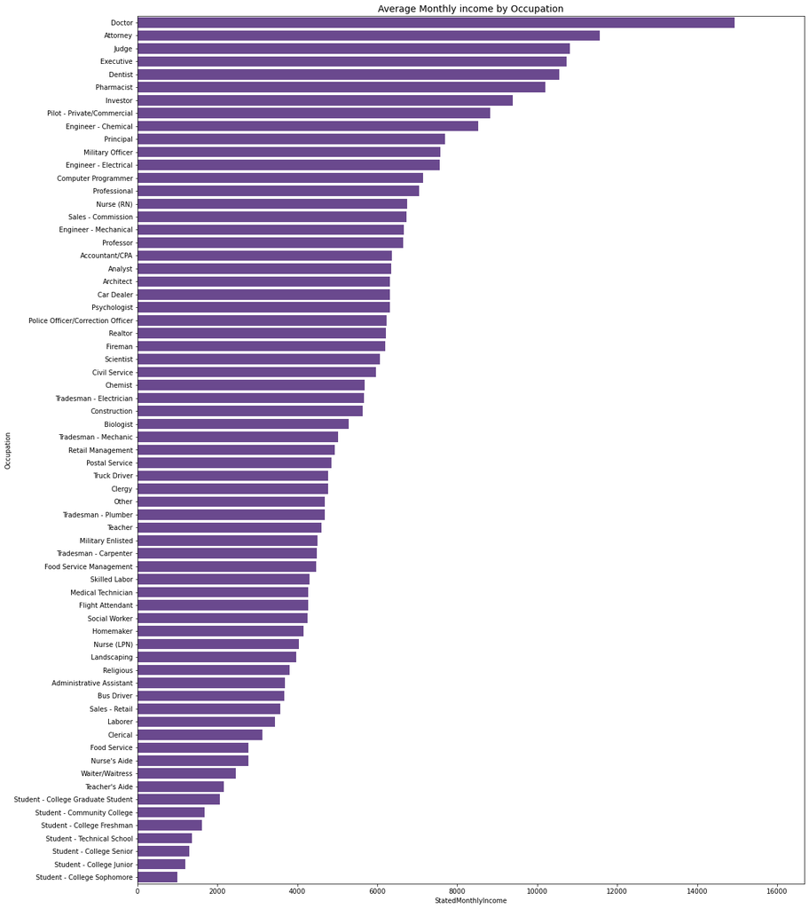

```python
# A visualization showing mean income based on occupation
Occupation = loandata.groupby('Occupation')['StatedMonthlyIncome'].mean()
Occupation = Occupation.sort_values(ascending = False).index
plt.figure(figsize = [18, 24])
base_color = sns.color_palette("Paired")[9]
sns.barplot(data = loandata, y = 'Occupation', x = 'StatedMonthlyIncome', color = base_color, errwidth = 0,
           order= Occupation)
plt.ylabel("Occupation")
plt.title("Average Monthly income by Occupation", fontsize = 14)
plt.xticks(rotation = 0);
```

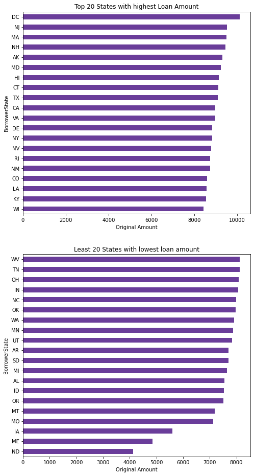

```python
#To discover the states where we have borrowers with high and low loan amount

plt.figure(figsize = [8, 16])

plt.subplot(2,1,1)
top_BorrowerState = loandata.groupby('BorrowerState').LoanOriginalAmount.mean().sort_values()[-20:]
top_BorrowerState.plot(kind = "barh", color = base_color)
plt.xlabel('Original Amount')
plt.title('Top 20 States with highest Loan Amount')

plt.subplot(2,1,2)
least_occupation = loandata.groupby('BorrowerState').LoanOriginalAmount.mean().sort_values()[:20]
least_occupation.plot(kind = "barh", color = base_color)
plt.xlabel('Original Amount')
plt.title('Least 20 States with lowest loan amount');
```

```python
#Numeric Variables
numeric_variables = ['Term', 'BorrowerAPR', 'BorrowerRate', 'LenderYield', 'ProsperScore',
                     'StatedMonthlyIncome', 'LoanOriginalAmount', 'MonthlyLoanPayment', 'LP_ServiceFees', 'Investors',
                    'AmountDelinquent','LoanCurrentDaysDelinquent']
```

```python
#Categorical Variables
categorical_variables = ['LoanStatus', 'ProsperRating (Alpha)', 'ListingCategory (numeric)', 'BorrowerState', 'Occupation',
                         'EmploymentStatus', 'IncomeRange']
```

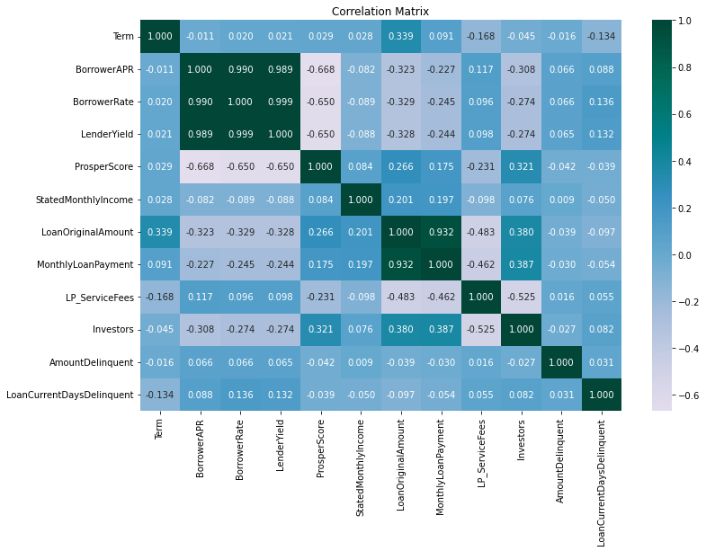

```python
# Correlation matrix for all numeric variables
plt.figure(figsize = [12, 8])
sns.heatmap(loandata[numeric_variables].corr(), annot = True, fmt = '.3f',
           cmap = 'PuBuGn', center = 0)
plt.title('Correlation Matrix')
plt.show()
```

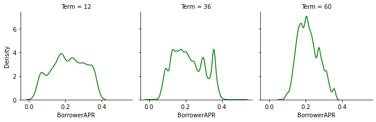

```python
# The Grid shows the distribution of Borrowers APR based on Term
plt.figure(figsize= (16,8))
base_color = sns.color_palette("Paired")[9]
g = sns.FacetGrid(data = loandata, col = 'Term')
g.map(sns.kdeplot, 'BorrowerAPR', color = "green")
```

- This demonstrates that borrowers with 0.2 APR in term 60 have a higher density of borrowers than borrowers with other APRs.

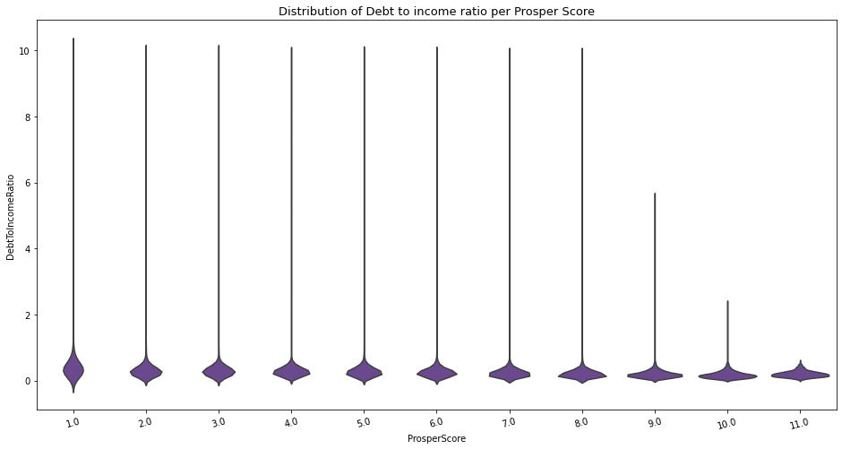

```python
# The Distribution of Debt to income ratio based on Prosper Score
plt.figure(figsize= (16,8))
base_color = sns.color_palette("Paired")[9]
sns.violinplot(data= loandata, x='ProsperScore', y='DebtToIncomeRatio', color=base_color, inner=None)
plt.title('Distribution of Debt to income ratio per Prosper Score', fontsize = 13)
plt.xticks(rotation=15);
```

# Multivariate

- The is to check if the loan orignal amount is connected to borrower term and home ownership status of the borrower
- Checking the impact on debt to income ration based on Employment status and loan term
- check for any relationship between the loan amount with respect to the Borrowers income bracket and Loan status

[figure not shown]

```python
#This is to check if the loan orignal amount is connected to borrower term and home ownership status of the borrower
plt.figure(figsize=[13,5])
sns.barplot(data = loandata, x = 'Term', y = 'LoanOriginalAmount', hue = 'IsBorrowerHomeowner',
            palette = 'Paired',ci = None)
plt.title('Loan Original Amount Across Employment status and Home Ownership')
plt.ylabel('Loan Original Amount')
plt.show()
```

- From the bar graph we can see that the term and loan original amount offered to borrowers is higher for homeowners than those who are not home owners.

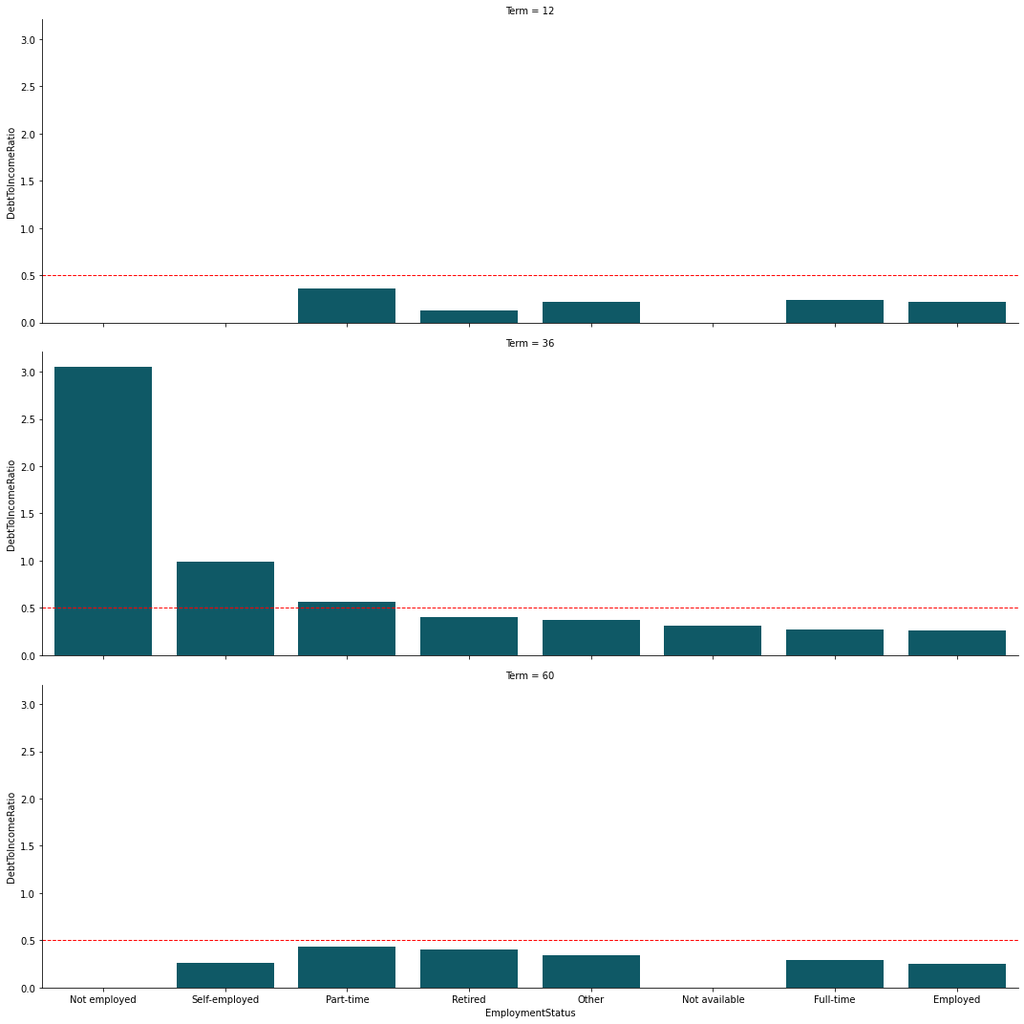

```python
# Checking the impact on debt to income ratio based on Employment status and loan term
plt.figure(figsize = (13, 7))
base_color = sns.color_palette("dark")[9]
loaned = loandata.groupby('EmploymentStatus')['DebtToIncomeRatio'].mean().sort_values(ascending = False)
g = sns.catplot(x = 'EmploymentStatus', y = 'DebtToIncomeRatio', kind = 'bar', data = loandata, ci = None,
            order = loaned.index, color = base_color, height = 5, aspect = 3, row = 'Term')
g.refline(y = 0.5, color = "red", lw = 1)
```

- We can see from the visualization and the criterion of 50% for the Debt to Income ratio that none of the borrowers in Terms 60 and 12 surpass the benchmark, indicating that they are not having trouble making their loan payments. In term 36, borrowers who are unemployed, self-employed, or working part-time have an average debt-to-income ratio that is higher than 0.5, which makes it difficult for them to repay their loans.

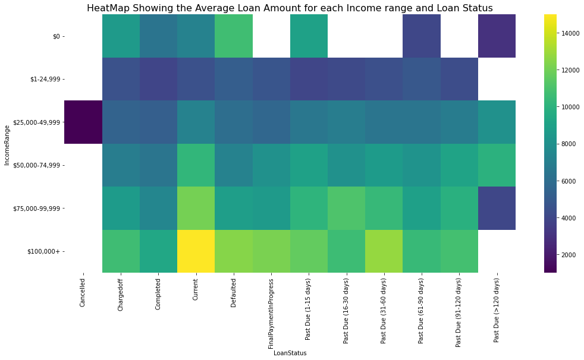

```python
# Visualization to check for any relationship between the loan amount with respect to the Borrowers income bracket and Loan status
plt.figure(figsize = (17,8))
group = loandata.groupby(['IncomeRange', 'LoanStatus'])['LoanOriginalAmount'].mean()
group = group.reset_index(name = 'Average Loan Amount')
group = group.pivot(index = 'IncomeRange', columns = 'LoanStatus', values = 'Average Loan Amount')
sns.heatmap(group, cmap = 'viridis')
plt.title('HeatMap Showing the Average Loan Amount for each Income range and Loan Status', fontsize = 16);
```

- It can be seen from the chart that borrowers with high income ranges ask for high loan amounts. The borrowers that received the largest loan amounts are in the Current Loan Status and earn between $100,000 and more annually.